# Risk Factor Analysis

## Outcome Variable

**Outcome Variable:** co_occurence

## Predictor Variables

**Intervention Variable:** ever_wasted06

**Adjustment Set:**

- sex
- arm
- brthmon
- single
- hhwealth_quart
- W_mage
- W_mhtcm
- W_meducyrs
- W_feducyrs
- delta_brthmon
- delta_single
- delta_hhwealth_quart
- delta_W_mage
- delta_W_mhtcm
- delta_W_meducyrs
- delta_W_feducyrs

## Stratifying Variables

The analysis was stratified on these variable(s):

- studyid
- country

## Data Summary

| studyid | country | ever_wasted06 | co_occurence | n_cell | n | outcome_variable |
| --- | --- | --- | --- | --- | --- | --- |
| CMC-V-BCS-2002 | INDIA | 0 | 0 | 171 | 366 | co_occurence |
| CMC-V-BCS-2002 | INDIA | 0 | 1 | 4 | 366 | co_occurence |
| CMC-V-BCS-2002 | INDIA | 1 | 0 | 173 | 366 | co_occurence |
| CMC-V-BCS-2002 | INDIA | 1 | 1 | 18 | 366 | co_occurence |
| CMIN | BANGLADESH | 0 | 0 | 179 | 237 | co_occurence |
| CMIN | BANGLADESH | 0 | 1 | 17 | 237 | co_occurence |
| CMIN | BANGLADESH | 1 | 0 | 32 | 237 | co_occurence |
| CMIN | BANGLADESH | 1 | 1 | 9 | 237 | co_occurence |
| COHORTS | GUATEMALA | 0 | 0 | 594 | 774 | co_occurence |
| COHORTS | GUATEMALA | 0 | 1 | 26 | 774 | co_occurence |
| COHORTS | GUATEMALA | 1 | 0 | 142 | 774 | co_occurence |
| COHORTS | GUATEMALA | 1 | 1 | 12 | 774 | co_occurence |
| COHORTS | PHILIPPINES | 0 | 0 | 1777 | 2487 | co_occurence |
| COHORTS | PHILIPPINES | 0 | 1 | 112 | 2487 | co_occurence |
| COHORTS | PHILIPPINES | 1 | 0 | 523 | 2487 | co_occurence |
| COHORTS | PHILIPPINES | 1 | 1 | 75 | 2487 | co_occurence |
| CONTENT | PERU | 0 | 0 | 197 | 200 | co_occurence |
| CONTENT | PERU | 0 | 1 | 0 | 200 | co_occurence |
| CONTENT | PERU | 1 | 0 | 3 | 200 | co_occurence |
| CONTENT | PERU | 1 | 1 | 0 | 200 | co_occurence |
| EE | PAKISTAN | 0 | 0 | 190 | 346 | co_occurence |
| EE | PAKISTAN | 0 | 1 | 35 | 346 | co_occurence |
| EE | PAKISTAN | 1 | 0 | 82 | 346 | co_occurence |
| EE | PAKISTAN | 1 | 1 | 39 | 346 | co_occurence |
| GMS-Nepal | NEPAL | 0 | 0 | 302 | 550 | co_occurence |
| GMS-Nepal | NEPAL | 0 | 1 | 28 | 550 | co_occurence |
| GMS-Nepal | NEPAL | 1 | 0 | 188 | 550 | co_occurence |
| GMS-Nepal | NEPAL | 1 | 1 | 32 | 550 | co_occurence |
| IRC | INDIA | 0 | 0 | 175 | 405 | co_occurence |
| IRC | INDIA | 0 | 1 | 10 | 405 | co_occurence |

[output cut: 78 more lines]

The following strata were considered:

- studyid: CMC-V-BCS-2002, country: INDIA
- studyid: CMIN, country: BANGLADESH
- studyid: COHORTS, country: GUATEMALA
- studyid: COHORTS, country: PHILIPPINES
- studyid: CONTENT, country: PERU
- studyid: EE, country: PAKISTAN
- studyid: GMS-Nepal, country: NEPAL
- studyid: IRC, country: INDIA
- studyid: JiVitA-4, country: BANGLADESH
- studyid: Keneba, country: GAMBIA
- studyid: LCNI-5, country: MALAWI
- studyid: MAL-ED, country: BANGLADESH
- studyid: MAL-ED, country: BRAZIL
- studyid: MAL-ED, country: INDIA
- studyid: MAL-ED, country: NEPAL
- studyid: MAL-ED, country: PERU
- studyid: MAL-ED, country: SOUTH AFRICA
- studyid: MAL-ED, country: TANZANIA, UNITED REPUBLIC OF
- studyid: NIH-Birth, country: BANGLADESH
- studyid: NIH-Crypto, country: BANGLADESH
- studyid: PROBIT, country: BELARUS
- studyid: PROVIDE, country: BANGLADESH
- studyid: ResPak, country: PAKISTAN
- studyid: SAS-CompFeed, country: INDIA
- studyid: SAS-FoodSuppl, country: INDIA
- studyid: TanzaniaChild2, country: TANZANIA, UNITED REPUBLIC OF
- studyid: ZVITAMBO, country: ZIMBABWE

### Dropped Strata

Some strata were dropped due to rare outcomes:

- studyid: CMC-V-BCS-2002, country: INDIA
- studyid: CONTENT, country: PERU
- studyid: LCNI-5, country: MALAWI
- studyid: MAL-ED, country: BANGLADESH
- studyid: MAL-ED, country: BRAZIL
- studyid: MAL-ED, country: INDIA
- studyid: MAL-ED, country: NEPAL
- studyid: MAL-ED, country: PERU
- studyid: MAL-ED, country: SOUTH AFRICA
- studyid: MAL-ED, country: TANZANIA, UNITED REPUBLIC OF
- studyid: PROBIT, country: BELARUS
- studyid: ResPak, country: PAKISTAN

## Methods Detail

We’re interested in the causal parameters $E[Y_a]$ for all values of $a \in \mathcal{A}$. These parameters represent the mean outcome if, possibly contrary to fact, we intervened to set all units to have $A=a$. Under the randomization and positivity assumptions, these are identified by the statistical parameters $\psi_a=E_W[E_{Y|A,W}(Y|A=a,W)]$. In addition, we’re interested in the mean of $Y$, $E[Y]$ under no intervention (the observed mean). We will estimate these parameters by using SuperLearner to fit the relevant likelihood factors – $E_{Y|A,W}(Y|A=a,W)$ and $p(A=a|W)$, and then updating our likelihood fit using a joint TMLE.

For unadjusted analyses ($W=\{\}$), initial likelihoods were estimated using Lrnr_glm to estimate the simple $E(Y|A)$ and Lrnr_mean to estimate $p(A)$. For adjusted analyses, a small library containing Lrnr_glmnet, Lrnr_xgboost, and Lrnr_mean was used.

Having estimated these parameters, we will then use the delta method to estimate relative risks and attributable risks relative to a prespecified baseline level of $A$.

# Results Detail

## Results Plots

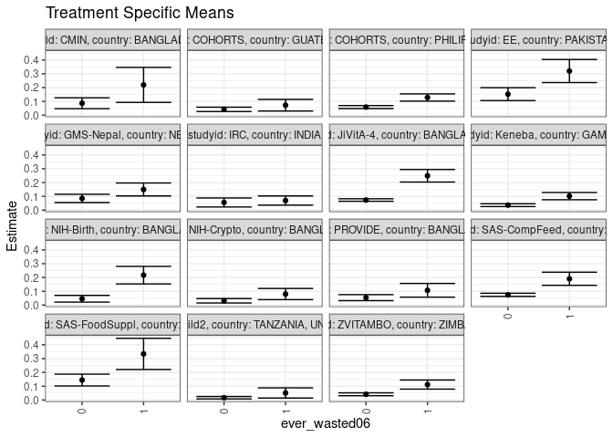

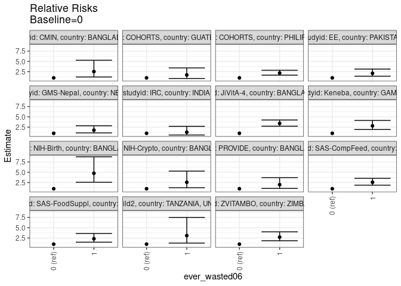

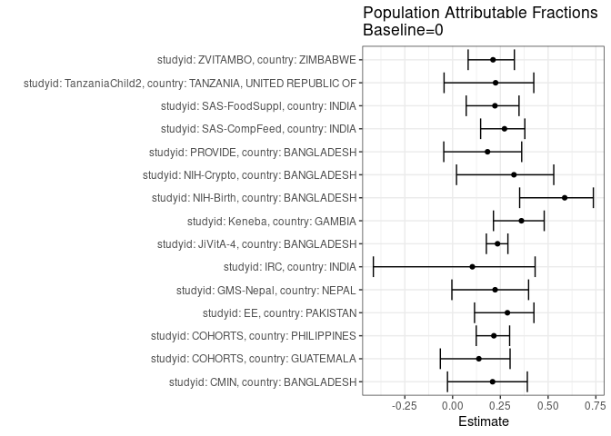

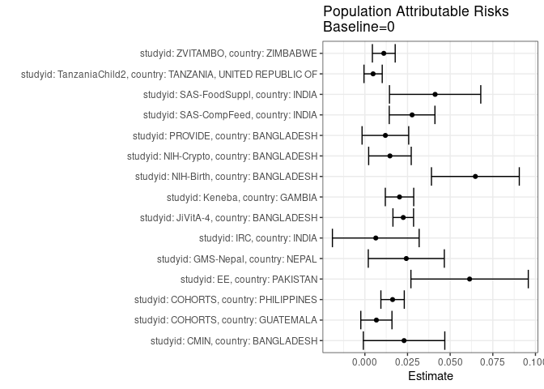

## Results Table

### Parameter: TSM

| studyid | country | intervention_level | baseline_level | estimate | ci_lower | ci_upper |
| --- | --- | --- | --- | --- | --- | --- |
| CMIN | BANGLADESH | 0 | NA | 0.0867347 | 0.0472496 | 0.1262198 |
| CMIN | BANGLADESH | 1 | NA | 0.2195122 | 0.0925464 | 0.3464780 |
| COHORTS | GUATEMALA | 0 | NA | 0.0423480 | 0.0264547 | 0.0582413 |
| COHORTS | GUATEMALA | 1 | NA | 0.0722996 | 0.0301927 | 0.1144066 |
| COHORTS | PHILIPPINES | 0 | NA | 0.0589501 | 0.0483213 | 0.0695789 |
| COHORTS | PHILIPPINES | 1 | NA | 0.1281272 | 0.1019479 | 0.1543064 |
| EE | PAKISTAN | 0 | NA | 0.1524805 | 0.1057011 | 0.1992599 |
| EE | PAKISTAN | 1 | NA | 0.3199539 | 0.2362503 | 0.4036575 |
| GMS-Nepal | NEPAL | 0 | NA | 0.0848110 | 0.0547433 | 0.1148788 |
| GMS-Nepal | NEPAL | 1 | NA | 0.1496804 | 0.1027771 | 0.1965838 |
| IRC | INDIA | 0 | NA | 0.0553392 | 0.0228112 | 0.0878673 |
| IRC | INDIA | 1 | NA | 0.0695144 | 0.0362485 | 0.1027803 |
| JiVitA-4 | BANGLADESH | 0 | NA | 0.0731522 | 0.0640942 | 0.0822102 |
| JiVitA-4 | BANGLADESH | 1 | NA | 0.2488422 | 0.2034663 | 0.2942181 |
| Keneba | GAMBIA | 0 | NA | 0.0360346 | 0.0258463 | 0.0462229 |
| Keneba | GAMBIA | 1 | NA | 0.1014740 | 0.0752902 | 0.1276578 |
| NIH-Birth | BANGLADESH | 0 | NA | 0.0456143 | 0.0212435 | 0.0699850 |
| NIH-Birth | BANGLADESH | 1 | NA | 0.2167889 | 0.1529592 | 0.2806185 |
| NIH-Crypto | BANGLADESH | 0 | NA | 0.0310480 | 0.0150936 | 0.0470025 |
| NIH-Crypto | BANGLADESH | 1 | NA | 0.0797265 | 0.0392867 | 0.1201664 |
| PROVIDE | BANGLADESH | 0 | NA | 0.0537014 | 0.0319868 | 0.0754160 |
| PROVIDE | BANGLADESH | 1 | NA | 0.1070063 | 0.0574164 | 0.1565962 |
| SAS-CompFeed | INDIA | 0 | NA | 0.0742322 | 0.0629744 | 0.0854900 |
| SAS-CompFeed | INDIA | 1 | NA | 0.1904254 | 0.1428027 | 0.2380480 |
| SAS-FoodSuppl | INDIA | 0 | NA | 0.1445823 | 0.1017386 | 0.1874259 |
| SAS-FoodSuppl | INDIA | 1 | NA | 0.3340792 | 0.2209986 | 0.4471597 |
| TanzaniaChild2 | TANZANIA, UNITED REPUBLIC OF | 0 | NA | 0.0166074 | 0.0079762 | 0.0252385 |
| TanzaniaChild2 | TANZANIA, UNITED REPUBLIC OF | 1 | NA | 0.0510949 | 0.0142048 | 0.0879850 |
| ZVITAMBO | ZIMBABWE | 0 | NA | 0.0412952 | 0.0307422 | 0.0518482 |
| ZVITAMBO | ZIMBABWE | 1 | NA | 0.1117669 | 0.0787556 | 0.1447782 |

### Parameter: E(Y)

| studyid | country | intervention_level | baseline_level | estimate | ci_lower | ci_upper |
| --- | --- | --- | --- | --- | --- | --- |
| CMIN | BANGLADESH | NA | NA | 0.1097046 | 0.0698323 | 0.1495770 |
| COHORTS | GUATEMALA | NA | NA | 0.0490956 | 0.0338639 | 0.0643273 |
| COHORTS | PHILIPPINES | NA | NA | 0.0751910 | 0.0648251 | 0.0855569 |
| EE | PAKISTAN | NA | NA | 0.2138728 | 0.1706052 | 0.2571404 |
| GMS-Nepal | NEPAL | NA | NA | 0.1090909 | 0.0830130 | 0.1351688 |
| IRC | INDIA | NA | NA | 0.0617284 | 0.0382610 | 0.0851958 |
| JiVitA-4 | BANGLADESH | NA | NA | 0.0956483 | 0.0855904 | 0.1057063 |
| Keneba | GAMBIA | NA | NA | 0.0563380 | 0.0456085 | 0.0670675 |
| NIH-Birth | BANGLADESH | NA | NA | 0.1103896 | 0.0817833 | 0.1389959 |
| NIH-Crypto | BANGLADESH | NA | NA | 0.0457413 | 0.0294659 | 0.0620168 |
| PROVIDE | BANGLADESH | NA | NA | 0.0657194 | 0.0452330 | 0.0862057 |
| SAS-CompFeed | INDIA | NA | NA | 0.1019108 | 0.0902026 | 0.1136190 |
| SAS-FoodSuppl | INDIA | NA | NA | 0.1857585 | 0.1432798 | 0.2282372 |
| TanzaniaChild2 | TANZANIA, UNITED REPUBLIC OF | NA | NA | 0.0214286 | 0.0123577 | 0.0304995 |
| ZVITAMBO | ZIMBABWE | NA | NA | 0.0523810 | 0.0417242 | 0.0630377 |

### Parameter: RR

| studyid | country | intervention_level | baseline_level | estimate | ci_lower | ci_upper |
| --- | --- | --- | --- | --- | --- | --- |
| CMIN | BANGLADESH | 0 | 0 | 1.000000 | 1.0000000 | 1.000000 |
| CMIN | BANGLADESH | 1 | 0 | 2.530846 | 1.2122647 | 5.283651 |
| COHORTS | GUATEMALA | 0 | 0 | 1.000000 | 1.0000000 | 1.000000 |
| COHORTS | GUATEMALA | 1 | 0 | 1.707273 | 0.8532611 | 3.416049 |
| COHORTS | PHILIPPINES | 0 | 0 | 1.000000 | 1.0000000 | 1.000000 |
| COHORTS | PHILIPPINES | 1 | 0 | 2.173486 | 1.6579093 | 2.849396 |
| EE | PAKISTAN | 0 | 0 | 1.000000 | 1.0000000 | 1.000000 |
| EE | PAKISTAN | 1 | 0 | 2.098327 | 1.4047789 | 3.134283 |
| GMS-Nepal | NEPAL | 0 | 0 | 1.000000 | 1.0000000 | 1.000000 |
| GMS-Nepal | NEPAL | 1 | 0 | 1.764869 | 1.0998552 | 2.831976 |
| IRC | INDIA | 0 | 0 | 1.000000 | 1.0000000 | 1.000000 |
| IRC | INDIA | 1 | 0 | 1.256150 | 0.5874255 | 2.686152 |
| JiVitA-4 | BANGLADESH | 0 | 0 | 1.000000 | 1.0000000 | 1.000000 |
| JiVitA-4 | BANGLADESH | 1 | 0 | 3.401704 | 2.7358496 | 4.229616 |
| Keneba | GAMBIA | 0 | 0 | 1.000000 | 1.0000000 | 1.000000 |
| Keneba | GAMBIA | 1 | 0 | 2.816016 | 1.9245337 | 4.120450 |
| NIH-Birth | BANGLADESH | 0 | 0 | 1.000000 | 1.0000000 | 1.000000 |
| NIH-Birth | BANGLADESH | 1 | 0 | 4.752656 | 2.5811600 | 8.751004 |
| NIH-Crypto | BANGLADESH | 0 | 0 | 1.000000 | 1.0000000 | 1.000000 |
| NIH-Crypto | BANGLADESH | 1 | 0 | 2.567845 | 1.2474278 | 5.285939 |
| PROVIDE | BANGLADESH | 0 | 0 | 1.000000 | 1.0000000 | 1.000000 |
| PROVIDE | BANGLADESH | 1 | 0 | 1.992617 | 1.0777214 | 3.684182 |
| SAS-CompFeed | INDIA | 0 | 0 | 1.000000 | 1.0000000 | 1.000000 |
| SAS-CompFeed | INDIA | 1 | 0 | 2.565265 | 1.8657959 | 3.526959 |
| SAS-FoodSuppl | INDIA | 0 | 0 | 1.000000 | 1.0000000 | 1.000000 |
| SAS-FoodSuppl | INDIA | 1 | 0 | 2.310651 | 1.4837885 | 3.598294 |
| TanzaniaChild2 | TANZANIA, UNITED REPUBLIC OF | 0 | 0 | 1.000000 | 1.0000000 | 1.000000 |
| TanzaniaChild2 | TANZANIA, UNITED REPUBLIC OF | 1 | 0 | 3.076642 | 1.2639518 | 7.488995 |
| ZVITAMBO | ZIMBABWE | 0 | 0 | 1.000000 | 1.0000000 | 1.000000 |
| ZVITAMBO | ZIMBABWE | 1 | 0 | 2.706535 | 1.8301643 | 4.002555 |

### Parameter: PAR

| studyid | country | intervention_level | baseline_level | estimate | ci_lower | ci_upper |
| --- | --- | --- | --- | --- | --- | --- |
| CMIN | BANGLADESH | 0 | NA | 0.0229699 | -0.0009080 | 0.0468479 |
| COHORTS | GUATEMALA | 0 | NA | 0.0067476 | -0.0023851 | 0.0158802 |
| COHORTS | PHILIPPINES | 0 | NA | 0.0162409 | 0.0093863 | 0.0230955 |
| EE | PAKISTAN | 0 | NA | 0.0613924 | 0.0269916 | 0.0957931 |
| GMS-Nepal | NEPAL | 0 | NA | 0.0242799 | 0.0019954 | 0.0465643 |
| IRC | INDIA | 0 | NA | 0.0063892 | -0.0190304 | 0.0318087 |
| JiVitA-4 | BANGLADESH | 0 | NA | 0.0224961 | 0.0164483 | 0.0285440 |
| Keneba | GAMBIA | 0 | NA | 0.0203034 | 0.0119758 | 0.0286310 |
| NIH-Birth | BANGLADESH | 0 | NA | 0.0647754 | 0.0390284 | 0.0905224 |
| NIH-Crypto | BANGLADESH | 0 | NA | 0.0146933 | 0.0022170 | 0.0271696 |
| PROVIDE | BANGLADESH | 0 | NA | 0.0120180 | -0.0016497 | 0.0256856 |
| SAS-CompFeed | INDIA | 0 | NA | 0.0276786 | 0.0142858 | 0.0410714 |
| SAS-FoodSuppl | INDIA | 0 | NA | 0.0411762 | 0.0144181 | 0.0679344 |
| TanzaniaChild2 | TANZANIA, UNITED REPUBLIC OF | 0 | NA | 0.0048212 | -0.0005279 | 0.0101703 |
| ZVITAMBO | ZIMBABWE | 0 | NA | 0.0110858 | 0.0043984 | 0.0177732 |

### Parameter: PAF

| studyid | country | intervention_level | baseline_level | estimate | ci_lower | ci_upper |
| --- | --- | --- | --- | --- | --- | --- |
| CMIN | BANGLADESH | 0 | NA | 0.2093799 | -0.0268154 | 0.3912439 |
| COHORTS | GUATEMALA | 0 | NA | 0.1374376 | -0.0642201 | 0.3008835 |
| COHORTS | PHILIPPINES | 0 | NA | 0.2159953 | 0.1237014 | 0.2985685 |
| EE | PAKISTAN | 0 | NA | 0.2870507 | 0.1148069 | 0.4257788 |
| GMS-Nepal | NEPAL | 0 | NA | 0.2225654 | -0.0037674 | 0.3978640 |
| IRC | INDIA | 0 | NA | 0.1035044 | -0.4149011 | 0.4319714 |
| JiVitA-4 | BANGLADESH | 0 | NA | 0.2351962 | 0.1766932 | 0.2895420 |
| Keneba | GAMBIA | 0 | NA | 0.3603858 | 0.2138872 | 0.4795832 |
| NIH-Birth | BANGLADESH | 0 | NA | 0.5867885 | 0.3510268 | 0.7369017 |
| NIH-Crypto | BANGLADESH | 0 | NA | 0.3212256 | 0.0204959 | 0.5296246 |
| PROVIDE | BANGLADESH | 0 | NA | 0.1828679 | -0.0462344 | 0.3618019 |
| SAS-CompFeed | INDIA | 0 | NA | 0.2715962 | 0.1467263 | 0.3781924 |
| SAS-FoodSuppl | INDIA | 0 | NA | 0.2216653 | 0.0712133 | 0.3477460 |
| TanzaniaChild2 | TANZANIA, UNITED REPUBLIC OF | 0 | NA | 0.2249901 | -0.0446753 | 0.4250459 |
| ZVITAMBO | ZIMBABWE | 0 | NA | 0.2116371 | 0.0813748 | 0.3234280 |